# Proyecto 1 - Modelos ARIMA/SARIMA

Juan Sebastian Angel Perez

## 1 Introducción

Para este trabajo se utilizó un conjunto de datos de comercio electrónico que contiene información sobre transacciones de ventas, incluyendo variables como fecha de orden, categoría de producto, precio, descuentos y valor total de la venta. A partir de esta base de datos se construyó una serie temporal utilizando la variable total_revenue, que representa los ingresos generados por las ventas.

Los datos originales corresponden a transacciones individuales, por lo que fue necesario realizar un proceso de agregación para obtener una serie temporal mensual de ingresos. De esta forma se generó una serie con observaciones mensuales correspondientes al período comprendido entre 2022 y 2023.

El objetivo de este trabajo es modelar el comportamiento de la serie temporal de ingresos mensuales mediante modelos ARIMA, siguiendo el procedimiento de Box-Jenkins. Para ello se analizan las propiedades estadísticas de la serie, se identifican modelos candidatos, se evalúan sus residuos y finalmente se generan pronósticos para evaluar la capacidad predictiva del modelo seleccionado.

## 2 Exploración de la serie original

En esta sección se realiza una exploración inicial de la serie temporal de ingresos mensuales obtenida a partir del conjunto de datos de ventas. El objetivo es observar el comportamiento general de la serie, identificar posibles patrones y evaluar visualmente la presencia de tendencia o estacionalidad.

```r
library(readr)
library(dplyr)
library(lubridate)
```

```r
library(ggplot2)
library(tseries)
library(forecast)
```

```r
data <- read.csv("data/amazon_sales_dataset.csv")
head(data)
```

```
##   order_id order_date product_id product_category  price discount_percent
## 1        1 2022-04-13       2637            Books 128.75               10
## 2        2 2023-03-12       2300          Fashion 302.60               20
## 3        3 2022-09-28       3670           Sports 495.80               20
## 4        4 2022-04-17       2522            Books 371.95               15
## 5        5 2022-03-13       1717           Beauty 201.68                0
## 6        6 2023-12-02       1777           Sports 385.17               30
##   quantity_sold customer_region payment_method rating review_count
## 1             4   North America            UPI    3.5          443
## 2             5            Asia    Credit Card    3.7          475
## 3             2          Europe            UPI    4.4          183
## 4             4     Middle East            UPI    5.0          212
## 5             4     Middle East            UPI    4.6          308
## 6             3            Asia         Wallet    3.8          489
##   discounted_price total_revenue
## 1           115.88        463.52
## 2           242.08       1210.40
## 3           396.64        793.28
## 4           316.16       1264.64
## 5           201.68        806.72
## 6           269.62        808.86
```

```r
str(data)
```

```
## 'data.frame':    50000 obs. of  13 variables:
##  $ order_id        : int  1 2 3 4 5 6 7 8 9 10 ...
##  $ order_date      : chr  "2022-04-13" "2023-03-12" "2022-09-28" "2022-04-17" ...
##  $ product_id      : int  2637 2300 3670 2522 1717 1777 4068 3537 3262 4174 ...
##  $ product_category: chr  "Books" "Fashion" "Sports" "Books" ...
##  $ price           : num  129 303 496 372 202 ...
##  $ discount_percent: int  10 20 20 15 0 30 0 30 0 15 ...
##  $ quantity_sold   : int  4 5 2 4 4 3 5 4 4 2 ...
##  $ customer_region : chr  "North America" "Asia" "Europe" "Middle East" ...
##  $ payment_method  : chr  "UPI" "Credit Card" "UPI" "UPI" ...
##  $ rating          : num  3.5 3.7 4.4 5 4.6 3.8 1.6 3.4 2.8 2 ...
##  $ review_count    : int  443 475 183 212 308 489 415 143 497 25 ...
##  $ discounted_price: num  116 242 397 316 202 ...
##  $ total_revenue   : num  464 1210 793 1265 807 ...
```

```r
data$order_date <- as.Date(data$order_date)
class(data$order_date)
```

```
## [1] "Date"
```

```r
monthly_sales <- data %>%
  mutate(month = floor_date(order_date, "month")) %>%
  group_by(month) %>%
  summarise(revenue = sum(total_revenue))

head(monthly_sales)
```

```
## # A tibble: 6 × 2
##   month       revenue
##   <date>        <dbl>
## 1 2022-01-01 1419752.
## 2 2022-02-01 1266714.
## 3 2022-03-01 1392585.
## 4 2022-04-01 1371956.
## 5 2022-05-01 1374780.
## 6 2022-06-01 1352125.
```

```r
nrow(monthly_sales)
```

```
## [1] 24
```

```r
revenue_ts <- ts(monthly_sales$revenue, frequency = 12, start = c(2022, 1))
revenue_ts
```

```
##          Jan     Feb     Mar     Apr     May     Jun     Jul     Aug     Sep
## 2022 1419752 1266714 1392585 1371956 1374780 1352125 1346089 1449308 1403967
## 2023 1464175 1238381 1366418 1307018 1431399 1394822 1442177 1396322 1341008
##          Oct     Nov     Dec
## 2022 1334818 1291100 1386210
## 2023 1425936 1334328 1335185
```

### 2.1 Gráfico de la serie original

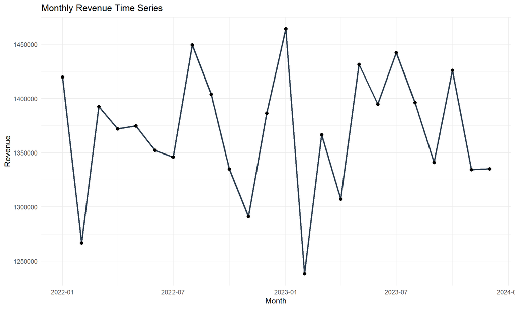

```r
ggplot(monthly_sales, aes(x = month, y = revenue)) +
  geom_line(color = "#2C3E50", linewidth = 1) +
  geom_point(size = 2) +
  labs(title = "Monthly Revenue Time Series",
       x = "Month",
       y = "Revenue") +
  theme_minimal()
```

El gráfico de la serie temporal de ingresos mensuales muestra la evolución del revenue generado por las ventas a lo largo del período analizado. En general, la serie presenta variaciones en el nivel de ingresos entre los diferentes meses, con algunos incrementos y disminuciones a lo largo del tiempo.

No se observa una tendencia claramente creciente o decreciente durante todo el período, aunque sí se presentan fluctuaciones en los valores mensuales. Asimismo, debido a que la serie contiene únicamente dos años de observaciones, no es posible identificar con claridad un patrón estacional definido.

La variabilidad de la serie parece mantenerse relativamente estable a lo largo del tiempo, sin evidencia clara de cambios significativos en la dispersión de los datos.

## 3 Proceso Box-Jenkins

El análisis de la serie temporal se realizó siguiendo el procedimiento de Box-Jenkins, el cual consiste en un proceso iterativo que incluye la identificación, estimación y verificación de modelos ARIMA. Este procedimiento permite seleccionar el modelo que mejor describe la dinámica de la serie temporal y que cumple con los supuestos estadísticos requeridos.

### 3.1 Verificación de estacionariedad

```r
adf_original <- adf.test(revenue_ts)
adf_original
```

```
##
##  Augmented Dickey-Fuller Test
##
## data:  revenue_ts
## Dickey-Fuller = -3.5353, Lag order = 2, p-value = 0.05898
## alternative hypothesis: stationary
```

Para evaluar si la serie temporal es estacionaria se aplicó la prueba de Dickey-Fuller aumentada (ADF). Esta prueba permite determinar si la serie presenta una raíz unitaria, lo que implicaría que no es estacionaria.

El resultado de la prueba ADF aplicada a la serie original arrojó un valor p de aproximadamente 0.05898. Dado que este valor es mayor que el nivel de significancia común de 0.05, no se rechaza la hipótesis nula de la prueba.

Por lo tanto, se concluye que la serie temporal original no es estacionaria, lo cual hace necesario aplicar transformaciones para poder modelarla adecuadamente mediante modelos ARIMA.

### 3.2 Transformación para lograr estacionariedad

```r
diff_revenue <- diff(revenue_ts)

diff_revenue
```

```
##             Jan        Feb        Mar        Apr        May        Jun
## 2022            -153037.60  125871.13  -20629.59    2823.74  -22654.08
## 2023   77965.38 -225794.48  128037.90  -59400.47  124380.83  -36576.64
##             Jul        Aug        Sep        Oct        Nov        Dec
## 2022   -6036.31  103218.88  -45341.00  -69148.95  -43718.06   95109.56
## 2023   47354.53  -45854.78  -55314.02   84928.37  -91607.76     856.86
```

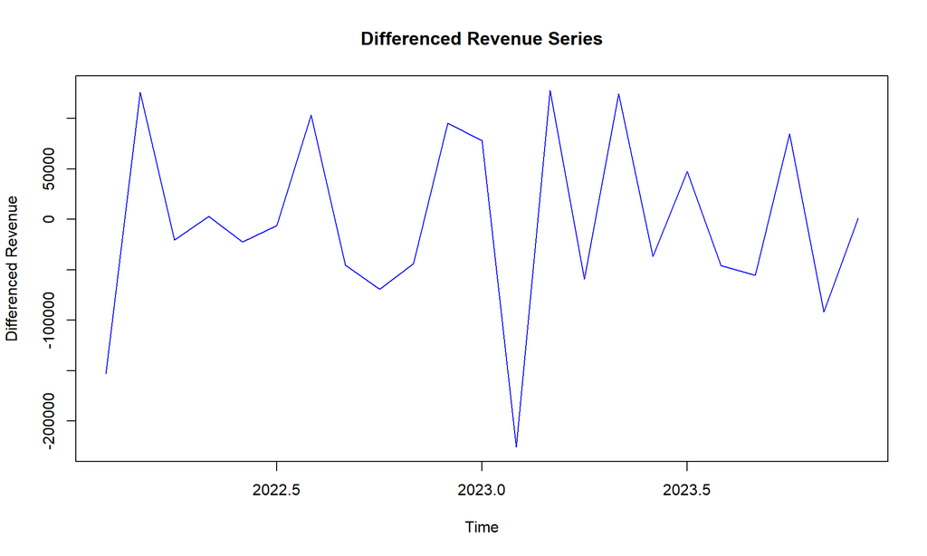

```r
plot(diff_revenue,
     main = "Differenced Revenue Series",
     ylab = "Differenced Revenue",
     col = "blue")
```

```r
adf_diff <- adf.test(diff_revenue)
adf_diff
```

```
##
##  Augmented Dickey-Fuller Test
##
## data:  diff_revenue
## Dickey-Fuller = -4.7735, Lag order = 2, p-value = 0.01
## alternative hypothesis: stationary
```

Dado que la prueba de Dickey-Fuller aumentada indicó que la serie original no es estacionaria, se aplicó una transformación mediante diferenciación de primer orden con el objetivo de estabilizar la media de la serie.

La diferenciación consiste en calcular la diferencia entre observaciones consecutivas de la serie temporal. Este procedimiento permite eliminar posibles tendencias y facilitar la aplicación de modelos ARIMA, los cuales requieren que la serie sea estacionaria.

Luego de aplicar la primera diferenciación, se volvió a realizar la prueba de Dickey-Fuller aumentada. El resultado arrojó un valor p menor que 0.05, lo que permitió rechazar la hipótesis nula de raíz unitaria. Por lo tanto, se concluye que la serie diferenciada es estacionaria.

En consecuencia, el orden de diferenciación utilizado en los modelos ARIMA estimados es $d = 1$.

### 3.3 Identificación del modelo (ACF y PACF)

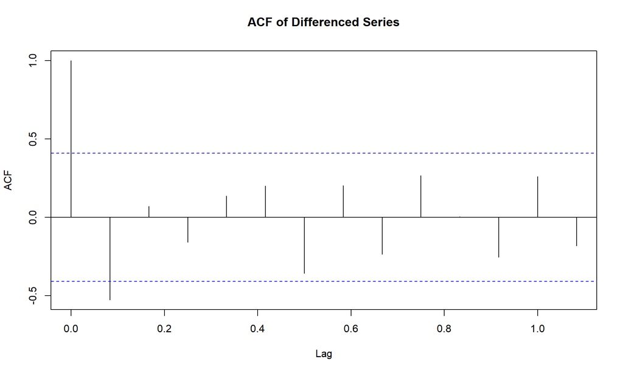

```r
acf(diff_revenue, main = "ACF of Differenced Series")
```

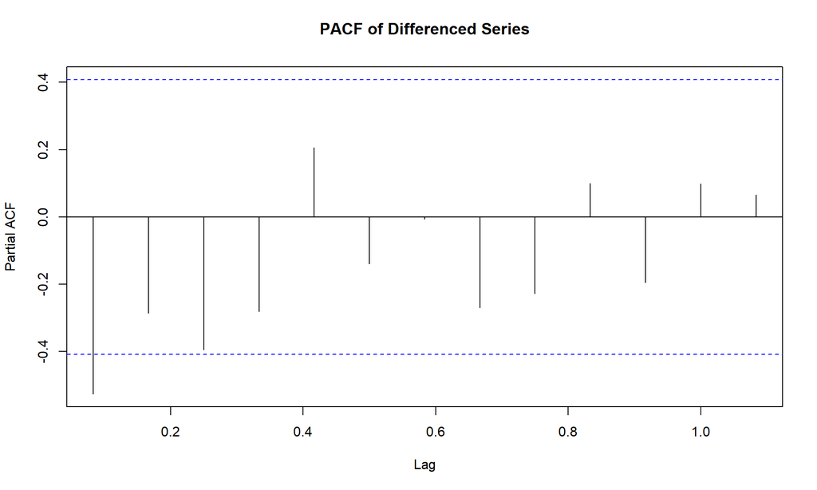

```r
pacf(diff_revenue, main = "PACF of Differenced Series")
```

Para identificar posibles modelos ARIMA se analizaron las funciones de autocorrelación (ACF) y autocorrelación parcial (PACF) de la serie diferenciada.

El gráfico de la ACF muestra un pico significativo en el primer rezago y posteriormente las autocorrelaciones se mantienen dentro de los límites de confianza. Este comportamiento es característico de procesos de media móvil de bajo orden.

Por su parte, la PACF no presenta un corte claro en un rezago específico, sino que las correlaciones parciales decrecen gradualmente. Este patrón sugiere la presencia de un componente autorregresivo pequeño o incluso nulo.

Con base en estos resultados se propusieron dos modelos candidatos para ser estimados y comparados posteriormente: ARIMA(0,1,1) y ARIMA(1,1,1).

### 3.4 Justificación de la no incorporación de componente estacional SARIMA

Aunque el enunciado del taller hace referencia a modelos SARIMA, en este caso no se incorporó un componente estacional explícito. Esta decisión se fundamenta en tres razones principales. En primer lugar, la serie analizada contiene únicamente 24 observaciones mensuales, lo cual equivale a dos ciclos anuales completos; esta cantidad es reducida para identificar con suficiente solidez una estructura estacional estable.

En segundo lugar, el gráfico de la serie original no muestra un patrón estacional claramente repetitivo entre un año y otro. Adicionalmente, en las funciones ACF y PACF de la serie diferenciada no se observan picos estacionales marcados en rezagos múltiplos de 12 que justifiquen la inclusión de términos estacionales $(P, D, Q)_{12}$.

Por estas razones, se consideró más apropiado ajustar modelos ARIMA no estacionales. No obstante, se deja explícito que esta decisión responde a las características particulares de la serie y a la ausencia de evidencia suficiente para especificar un componente SARIMA de forma robusta.

## 4 Estimación de modelos

Con base en el análisis de las funciones de autocorrelación y autocorrelación parcial se estimaron dos modelos candidatos: ARIMA(0,1,1) y ARIMA(1,1,1). Estos modelos fueron estimados con el objetivo de comparar su desempeño y seleccionar el modelo que mejor se ajusta a la serie temporal.

### 4.1 Modelo ARIMA(0,1,1)

```r
model1 <- arima(revenue_ts, order = c(0,1,1))
model1
```

```
##
## Call:
## arima(x = revenue_ts, order = c(0, 1, 1))
##
## Coefficients:
##           ma1
##       -1.0000
## s.e.   0.1173
##
## sigma^2 estimated as 3.332e+09:  log likelihood = -286.38,  aic = 576.77
```

### 4.2 Modelo ARIMA(1,1,1)

```r
model2 <- arima(revenue_ts, order = c(1,1,1))
model2
```

```
##
## Call:
## arima(x = revenue_ts, order = c(1, 1, 1))
##
## Coefficients:
##           ar1      ma1
##       -0.2024  -1.0000
## s.e.   0.2060   0.1299
##
## sigma^2 estimated as 3.146e+09:  log likelihood = -285.92,  aic = 577.84
```

## 5 Verificación de residuos

### 5.1 Diagnóstico del modelo ARIMA(0,1,1)

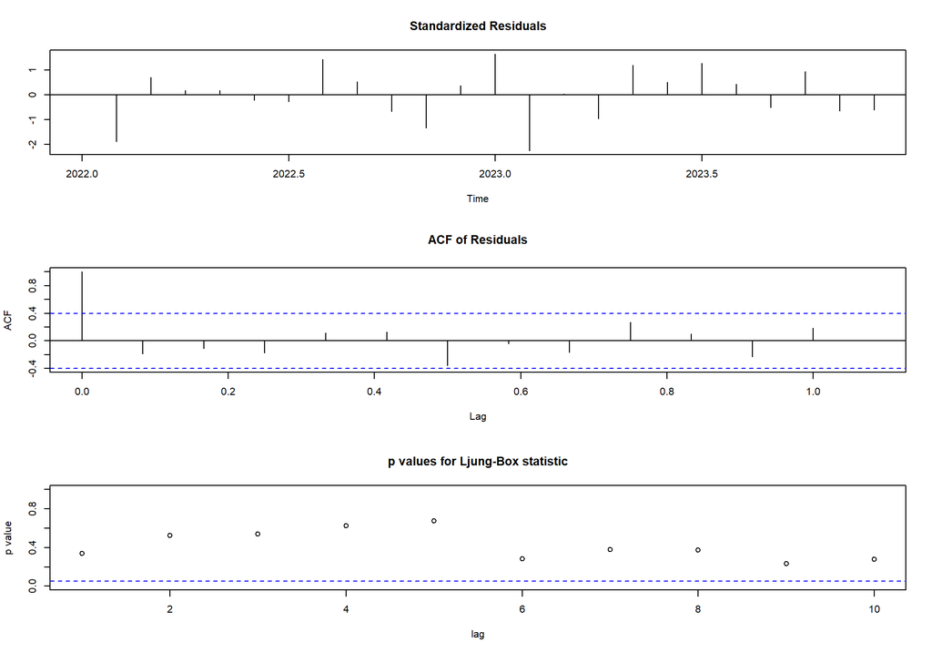

```r
tsdiag(model1)
```

### 5.2 Diagnóstico del modelo ARIMA(1,1,1)

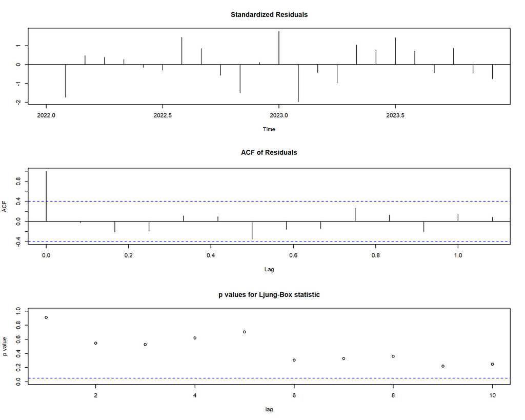

```r
tsdiag(model2)
```

Con el fin de evaluar la validez de los modelos estimados, se realizó un análisis de los residuos para los modelos ARIMA(0,1,1) y ARIMA(1,1,1). Este análisis permite verificar si los residuos se comportan como ruido blanco, lo cual es un supuesto fundamental para que el modelo sea considerado adecuado.

En ambos modelos, el gráfico de los residuos estandarizados muestra fluctuaciones alrededor de cero sin la presencia de patrones sistemáticos evidentes. Esto sugiere que los modelos logran capturar adecuadamente la estructura temporal de la serie.

El análisis de la función de autocorrelación de los residuos indica que la mayoría de las autocorrelaciones se encuentran dentro de los límites de confianza, lo que sugiere la ausencia de autocorrelación significativa en los residuos.

Adicionalmente, los valores p asociados a la prueba de Ljung-Box para diferentes rezagos son mayores que el nivel de significancia de 0.05 en ambos modelos. Por lo tanto, no se rechaza la hipótesis nula de independencia de los residuos.

En conjunto, estos resultados indican que los residuos de ambos modelos se comportan aproximadamente como ruido blanco, lo cual respalda la adecuación estadística de los modelos estimados. Dado que ambos modelos cumplen razonablemente con los supuestos del análisis de residuos, la selección final del modelo se realizará utilizando criterios de información y métricas de pronóstico.

## 6 Selección del modelo

```r
aic_model1 <- model1$aic
aic_model2 <- model2$aic

sigma2_model1 <- model1$sigma2
sigma2_model2 <- model2$sigma2

comparison_fit <- data.frame(
  Modelo = c("ARIMA(0,1,1)", "ARIMA(1,1,1)"),
  AIC = c(aic_model1, aic_model2),
  Varianza_Residual = c(sigma2_model1, sigma2_model2)
)

comparison_fit
```

```
##         Modelo      AIC Varianza_Residual
## 1 ARIMA(0,1,1) 576.7699        3332487968
## 2 ARIMA(1,1,1) 577.8446        3146429095
```

Para seleccionar el modelo más adecuado se compararon los modelos ARIMA(0,1,1) y ARIMA(1,1,1) utilizando criterios de información y medidas de ajuste.

El modelo ARIMA(0,1,1) presentó un menor valor del criterio de información de Akaike (AIC) en comparación con el modelo ARIMA(1,1,1). Dado que un menor valor de AIC indica un mejor equilibrio entre calidad de ajuste y complejidad del modelo, se seleccionó el modelo ARIMA(0,1,1) como el modelo final.

Además, el análisis de residuos mostró que ambos modelos son estadísticamente válidos, por lo que el criterio de información y el desempeño predictivo resultan determinantes para la selección.

La representación matemática del modelo seleccionado se expresa mediante la siguiente ecuación:

$$(1 - B)Y_t = (1 - \theta_1 B)\varepsilon_t$$
donde $B$ es el operador de rezago, $Y_t$ representa el valor de la serie en el tiempo $t$, $\theta_1$ es el parámetro del componente de media móvil y $\varepsilon_t$ es un término de error aleatorio con media cero y varianza constante.

## 7 Pronósticos y evaluación predictiva

Una vez seleccionados los modelos candidatos, se procedió a evaluar su capacidad predictiva mediante un esquema de validación utilizando muestras de entrenamiento y prueba.

### 7.1 División Train/Test

```r
train <- window(revenue_ts, end = c(2023, 6))
test <- window(revenue_ts, start = c(2023, 7))

train
```

```
##          Jan     Feb     Mar     Apr     May     Jun     Jul     Aug     Sep
## 2022 1419752 1266714 1392585 1371956 1374780 1352125 1346089 1449308 1403967
## 2023 1464175 1238381 1366418 1307018 1431399 1394822
##          Oct     Nov     Dec
## 2022 1334818 1291100 1386210
## 2023
```

```r
test
```

```
##          Jul     Aug     Sep     Oct     Nov     Dec
## 2023 1442177 1396322 1341008 1425936 1334328 1335185
```

```r
length(train)
```

```
## [1] 18
```

```r
length(test)
```

```
## [1] 6
```

Para evaluar la capacidad predictiva de los modelos, la serie temporal se dividió en un conjunto de entrenamiento y un conjunto de prueba. Los primeros 18 meses fueron utilizados para estimar los modelos, mientras que los últimos 6 meses se reservaron para evaluar el desempeño de los pronósticos fuera de muestra.

### 7.2 Pronósticos de ambos modelos

```r
model1_train <- arima(train, order = c(0,1,1))
model2_train <- arima(train, order = c(1,1,1))

forecast_model1 <- forecast(model1_train, h = length(test))
forecast_model2 <- forecast(model2_train, h = length(test))

pred1 <- forecast_model1$mean
pred2 <- forecast_model2$mean

forecast_model1
```

```
##          Point Forecast   Lo 80   Hi 80   Lo 95   Hi 95
## Jul 2023        1366201 1285389 1447012 1242610 1489791
## Aug 2023        1366201 1285389 1447012 1242610 1489791
## Sep 2023        1366201 1285389 1447012 1242610 1489791
## Oct 2023        1366201 1285389 1447012 1242610 1489791
## Nov 2023        1366201 1285389 1447012 1242610 1489791
## Dec 2023        1366201 1285389 1447012 1242610 1489791
```

```r
forecast_model2
```

```
##          Point Forecast   Lo 80   Hi 80   Lo 95   Hi 95
## Jul 2023        1357593 1280508 1434679 1239702 1475485
## Aug 2023        1367218 1288644 1445793 1247049 1487388
## Sep 2023        1364730 1285785 1443675 1243995 1485465
## Oct 2023        1365373 1286474 1444273 1244707 1486039
## Nov 2023        1365207 1286293 1444121 1244518 1485896
## Dec 2023        1365250 1286339 1444161 1244567 1485933
```

```r
pred1
```

```
##          Jul     Aug     Sep     Oct     Nov     Dec
## 2023 1366201 1366201 1366201 1366201 1366201 1366201
```

```r
pred2
```

```
##          Jul     Aug     Sep     Oct     Nov     Dec
## 2023 1357593 1367218 1364730 1365373 1365207 1365250
```

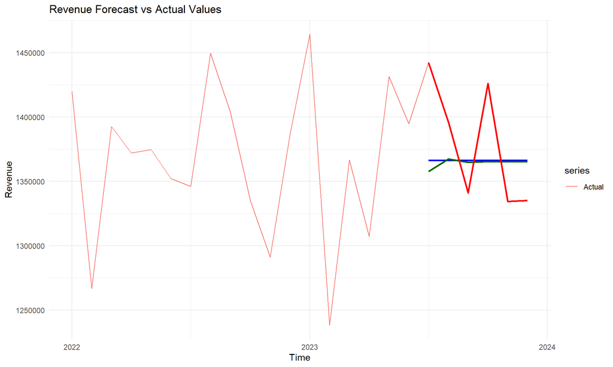

```r
autoplot(revenue_ts, series = "Actual") +
  autolayer(ts(pred1, start = start(test), frequency = 12),
            series = "Forecast ARIMA(0,1,1)",
            color = "blue",
            linewidth = 1) +
  autolayer(ts(pred2, start = start(test), frequency = 12),
            series = "Forecast ARIMA(1,1,1)",
            color = "darkgreen",
            linewidth = 1) +
  autolayer(test,
            series = "Test",
            color = "red",
            linewidth = 1) +
  labs(title = "Revenue Forecast vs Actual Values",
       x = "Time",
       y = "Revenue") +
  theme_minimal()
```

En la gráfica anterior se comparan los pronósticos generados por ambos modelos con los valores reales de la muestra de prueba. Se observa que los valores pronosticados tienden a estabilizarse alrededor de un nivel constante, lo cual es consistente con el comportamiento esperado en modelos de bajo orden con diferenciación.

### 7.3 Evaluación del pronóstico (MSE y MAPE)

```r
mse_model1_test <- mean((test - pred1)^2)
mape_model1_test <- mean(abs((test - pred1) / test)) * 100

mse_model2_test <- mean((test - pred2)^2)
mape_model2_test <- mean(abs((test - pred2) / test)) * 100

metrics_test <- data.frame(
  Modelo = c("ARIMA(0,1,1)", "ARIMA(1,1,1)"),
  MSE_Test = c(mse_model1_test, mse_model2_test),
  MAPE_Test = c(mape_model1_test, mape_model2_test)
)

metrics_test
```

```
##         Modelo   MSE_Test MAPE_Test
## 1 ARIMA(0,1,1) 2143401341  3.034125
## 2 ARIMA(1,1,1) 2348218341  3.088561
```

```r
fitted1 <- train - residuals(model1_train)
fitted2 <- train - residuals(model2_train)

mse_model1_train <- mean((train - fitted1)^2, na.rm = TRUE)
mape_model1_train <- mean(abs((train - fitted1) / train), na.rm = TRUE) * 100

mse_model2_train <- mean((train - fitted2)^2, na.rm = TRUE)
mape_model2_train <- mean(abs((train - fitted2) / train), na.rm = TRUE) * 100

metrics_train <- data.frame(
  Modelo = c("ARIMA(0,1,1)", "ARIMA(1,1,1)"),
  MSE_Train = c(mse_model1_train, mse_model2_train),
  MAPE_Train = c(mape_model1_train, mape_model2_train)
)

metrics_train
```

```
##         Modelo  MSE_Train MAPE_Train
## 1 ARIMA(0,1,1) 3557831785   3.425127
## 2 ARIMA(1,1,1) 3233301784   3.398648
```

```r
metrics_summary <- comparison_fit %>%
  left_join(metrics_train, by = "Modelo") %>%
  left_join(metrics_test, by = "Modelo")

metrics_summary
```

```
##         Modelo      AIC Varianza_Residual  MSE_Train MAPE_Train   MSE_Test
## 1 ARIMA(0,1,1) 576.7699        3332487968 3557831785   3.425127 2143401341
## 2 ARIMA(1,1,1) 577.8446        3146429095 3233301784   3.398648 2348218341
##   MAPE_Test
## 1  3.034125
## 2  3.088561
```

Para evaluar el desempeño predictivo de los modelos se calcularon dos métricas: el Error Cuadrático Medio (MSE) y el Error Porcentual Absoluto Medio (MAPE), tanto en la muestra de entrenamiento como en la muestra de prueba.

La comparación muestra que el modelo ARIMA(0,1,1) presenta el menor AIC y un desempeño predictivo competitivo en términos de MSE y MAPE. Por esta razón, y considerando además la parsimonia del modelo, se mantiene como la mejor alternativa para describir y pronosticar la serie temporal analizada.

### 7.4 Validación Cruzada

```r
tsCV_mse_mape <- function(y, order, initial) {

  n <- length(y)
  errors <- c()
  actuals <- c()

  for (i in seq(initial, n - 1)) {
    train_cv <- y[1:i]
    test_cv <- y[i + 1]

    fit_cv <- try(arima(train_cv, order = order), silent = TRUE)

    if (!inherits(fit_cv, "try-error")) {
      fc_cv <- forecast(fit_cv, h = 1)$mean[1]
      errors <- c(errors, test_cv - fc_cv)
      actuals <- c(actuals, test_cv)
    }
  }

  mse <- mean(errors^2, na.rm = TRUE)
  mape <- mean(abs(errors / actuals), na.rm = TRUE) * 100

  data.frame(
    MSE_CV = mse,
    MAPE_CV = mape,
    N_Validaciones = length(errors)
  )
}
```

```r
cv_model1 <- tsCV_mse_mape(revenue_ts, order = c(0,1,1), initial = 18)
cv_model2 <- tsCV_mse_mape(revenue_ts, order = c(1,1,1), initial = 18)

cv_comparison <- data.frame(
  Modelo = c("ARIMA(0,1,1)", "ARIMA(1,1,1)"),
  MSE_CV = c(cv_model1$MSE_CV, cv_model2$MSE_CV),
  MAPE_CV = c(cv_model1$MAPE_CV, cv_model2$MAPE_CV),
  N_Validaciones = c(cv_model1$N_Validaciones, cv_model2$N_Validaciones)
)

cv_comparison
```

```
##         Modelo     MSE_CV  MAPE_CV N_Validaciones
## 1 ARIMA(0,1,1) 2208264471 3.146177              6
## 2 ARIMA(1,1,1) 2476817631 3.281876              6
```

En complemento a la partición train/test, se realizó un análisis de validación cruzada de tipo recursivo con ventana creciente. Para ello se dejó inicialmente un bloque de 18 observaciones para estimación, y posteriormente se generaron pronósticos de un paso adelante, incorporando progresivamente nuevas observaciones al conjunto de entrenamiento.

Este procedimiento permitió comparar el poder predictivo de los modelos ARIMA(0,1,1) y ARIMA(1,1,1) en varios puntos de la serie. El criterio de selección se basó en los valores obtenidos de MSE y MAPE bajo validación cruzada, considerando como mejor modelo aquel que presenta menores errores de pronóstico.

Los resultados de la validación cruzada confirman la conveniencia de seleccionar el modelo ARIMA(0,1,1), ya que presenta un mejor equilibrio entre parsimonia, ajuste estadístico y capacidad predictiva.

## 8 Modelo SARIMAX (Ejercicio adicional)

```r
monthly_discount <- data %>%
  mutate(month = floor_date(order_date, "month")) %>%
  group_by(month) %>%
  summarise(avg_discount = mean(discount_percent), .groups = "drop")

discount_ts <- ts(monthly_discount$avg_discount, frequency = 12, start = c(2022,1))

head(monthly_discount)
```

```
## # A tibble: 6 × 2
##   month      avg_discount
##   <date>            <dbl>
## 1 2022-01-01         13.0
## 2 2022-02-01         13.2
## 3 2022-03-01         13.6
## 4 2022-04-01         13.3
## 5 2022-05-01         13.5
## 6 2022-06-01         13.3
```

```r
discount_ts
```

```
##           Jan      Feb      Mar      Apr      May      Jun      Jul      Aug
## 2022 12.98001 13.17799 13.58469 13.29584 13.50458 13.30479 13.89632 13.31658
## 2023 13.41792 13.22710 13.27455 13.12719 13.40994 13.10741 13.31002 13.41582
##           Sep      Oct      Nov      Dec
## 2022 13.17619 13.57039 13.32250 13.15726
## 2023 13.34235 13.11950 13.61167 13.51430
```

```r
sarimax_model <- arima(revenue_ts,
                       order = c(0,1,1),
                       xreg = discount_ts)

sarimax_model
```

```
##
## Call:
## arima(x = revenue_ts, order = c(0, 1, 1), xreg = discount_ts)
##
## Coefficients:
##           ma1  discount_ts
##       -1.0000    -19552.32
## s.e.   0.1174     58886.69
##
## sigma^2 estimated as 3.317e+09:  log likelihood = -286.33,  aic = 578.66
```

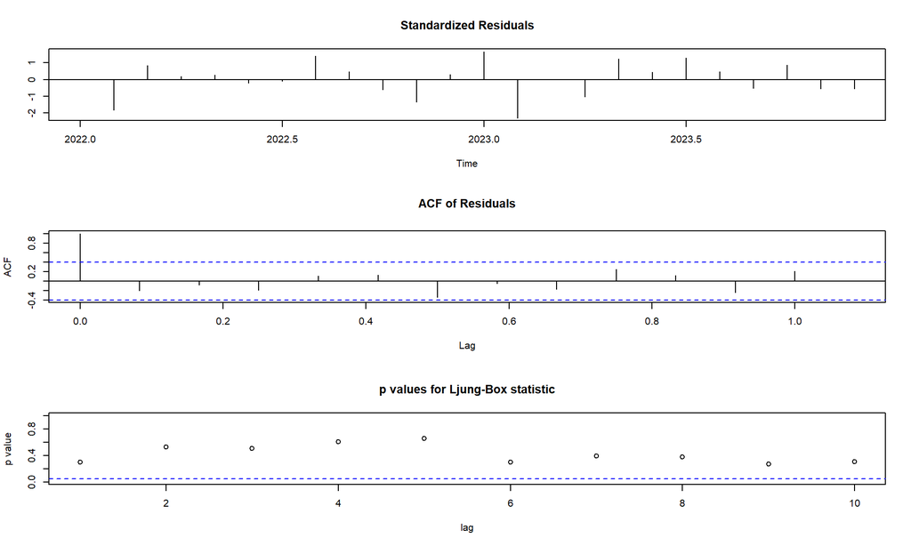

```r
tsdiag(sarimax_model)
```

Como ejercicio adicional se estimó un modelo SARIMAX con el objetivo de evaluar si una variable externa puede mejorar la capacidad explicativa del modelo. En este caso se utilizó como variable exógena el descuento promedio mensual, calculado a partir de la variable discount_percent del conjunto de datos original.

El modelo estimado corresponde a un SARIMAX(0,1,1), donde la serie de ingresos mensuales se modela incorporando el descuento promedio mensual como variable explicativa. Los resultados del modelo muestran un coeficiente negativo asociado a la variable de descuento, lo que sugiere que incrementos en el descuento promedio mensual estarían asociados con reducciones en el revenue esperado, manteniendo constante la dinámica temporal del modelo.

Sin embargo, al comparar los criterios de información se observa que el modelo SARIMAX presenta un valor de AIC mayor que el modelo ARIMA(0,1,1) estimado previamente. Esto indica que la inclusión de la variable exógena no mejora el ajuste del modelo.

El análisis de residuos del modelo SARIMAX muestra que los residuos se comportan como ruido blanco. La función de autocorrelación de los residuos no presenta correlaciones significativas y los p-values del test de Ljung-Box se mantienen por encima del nivel de significancia del 5%, lo que indica ausencia de autocorrelación residual.

En conclusión, aunque el modelo SARIMAX es estadísticamente válido, la inclusión de la variable de descuento no mejora el desempeño del modelo respecto al ARIMA(0,1,1), por lo que el modelo ARIMA simple continúa siendo la mejor alternativa para describir y pronosticar la serie temporal analizada.

## 9 Conclusiones

En este trabajo se aplicó la metodología de Box-Jenkins para modelar una serie temporal de ingresos mensuales obtenida a partir de datos de ventas de comercio electrónico.

El análisis inicial mostró que la serie original no era estacionaria, por lo que fue necesario aplicar una diferenciación de primer orden. Posteriormente se analizaron las funciones de autocorrelación y autocorrelación parcial, lo que permitió identificar dos modelos candidatos: ARIMA(0,1,1) y ARIMA(1,1,1).

Luego de estimar ambos modelos y realizar el análisis de residuos, se observó que los dos modelos son estadísticamente válidos. Sin embargo, la comparación mediante AIC, métricas de pronóstico y validación cruzada mostró que el modelo ARIMA(0,1,1) ofrece el mejor equilibrio entre simplicidad, ajuste y capacidad predictiva.

La evaluación del desempeño predictivo mediante la división train/test y las métricas MSE y MAPE evidenció que el modelo presenta una buena capacidad de pronóstico para la serie analizada. Además, la validación cruzada confirmó que este modelo mantiene un desempeño consistente en diferentes puntos de la serie.

Aunque el taller plantea el uso de modelos SARIMA, en este caso no se incorporó una componente estacional debido a la limitada longitud de la serie y a la ausencia de evidencia visual y estadística suficientemente fuerte de estacionalidad. Esta decisión permitió construir un modelo más parsimonioso y coherente con las características de los datos.

Adicionalmente, se estimó un modelo SARIMAX como ejercicio complementario incorporando una variable exógena correspondiente al descuento promedio mensual. Sin embargo, la inclusión de esta variable no mejoró el ajuste del modelo en comparación con el ARIMA simple.

En conclusión, el modelo ARIMA(0,1,1) resulta adecuado para describir y pronosticar el comportamiento de la serie temporal analizada.